# Td Synthese

Cléo Le Bastard Courson Quentin

2025-12-08

# Librairie

```r
library(tidyr)
library(readr)
library(kableExtra)
```

# Chargement des données

```r
data <- read_delim("autoroutes_2025.csv",
    delim = ";", escape_double = FALSE, trim_ws = TRUE)
```

# Statistiques descriptives

```r
dim(data)
```

```
## [1] 192   2
```

Il y a 192 lignes pour 2 colonnes.

```r
summary(data)
```

```
##      Date               Veh_km
##  Length:192         Min.   : 3.069
##  Class :character   1st Qu.:11.402
##  Mode  :character   Median :12.375
##                     Mean   :12.619
##                     3rd Qu.:13.733
##                     Max.   :17.288
```

# Conversion du format de la date

```r
# Convertir en format Date
data$Date=as.Date(data$Date, format="%Y:%m:%d")
```

# Manipulation dates:

```r
data$Annee=format(x=data$Date, format="%Y")
data$Mois=format(x = data$Date, format="%m")
data$Moisl=format(x = data$Date, format="%B")
```

# Tableau de Buys-Ballot

```r
tab_buba=pivot_wider(data, names_from = Mois,id_cols=Annee, values_from = Veh_km)
kable(tab_buba)
```

| Annee | 01 | 02 | 03 | 04 | 05 | 06 | 07 | 08 | 09 | 10 | 11 | 12 |
| --- | --- | --- | --- | --- | --- | --- | --- | --- | --- | --- | --- | --- |
| 2009 | 9.743 | 9.829 | 10.871 | 11.983 | 12.134 | 12.060 | 14.580 | 14.842 | 11.697 | 11.649 | 10.339 | 11.032 |
| 2010 | 9.756 | 9.939 | 11.059 | 12.549 | 12.390 | 12.226 | 15.005 | 14.864 | 12.075 | 11.893 | 10.615 | 10.921 |
| 2011 | 10.249 | 10.093 | 11.347 | 12.262 | 11.982 | 12.760 | 15.126 | 14.703 | 12.201 | 12.060 | 10.640 | 11.438 |
| 2012 | 10.198 | 9.769 | 11.307 | 11.860 | 11.999 | 12.201 | 14.728 | 14.706 | 12.098 | 11.627 | 10.844 | 10.977 |
| 2013 | 9.870 | 9.554 | 11.412 | 11.556 | 12.376 | 12.359 | 14.878 | 15.287 | 12.137 | 12.091 | 10.675 | 11.370 |
| 2014 | 10.321 | 9.872 | 11.522 | 12.099 | 12.130 | 12.923 | 14.746 | 15.571 | 12.248 | 12.374 | 10.706 | 11.712 |
| 2015 | 10.529 | 10.415 | 11.559 | 12.471 | 13.032 | 12.834 | 15.492 | 15.913 | 12.570 | 12.767 | 10.935 | 12.163 |
| 2016 | 10.812 | 10.953 | 12.177 | 12.589 | 12.931 | 13.045 | 16.088 | 15.905 | 12.867 | 12.875 | 11.351 | 12.364 |
| 2017 | 10.901 | 11.034 | 12.155 | 13.330 | 13.130 | 13.467 | 16.197 | 16.145 | 13.297 | 13.240 | 11.734 | 12.404 |
| 2018 | 11.324 | 10.671 | 12.651 | 13.398 | 13.743 | 13.608 | 16.237 | 16.359 | 13.403 | 13.300 | 11.052 | 11.619 |
| 2019 | 11.180 | 11.171 | 12.613 | 13.491 | 12.932 | 14.026 | 16.003 | 16.558 | 13.349 | 13.488 | 11.895 | 13.211 |
| 2020 | 12.086 | 11.908 | 7.678 | 3.069 | 6.561 | 11.823 | 15.733 | 16.326 | 12.866 | 12.658 | 7.454 | 10.844 |
| 2021 | 10.054 | 9.958 | 10.617 | 9.191 | 12.332 | 13.302 | 16.833 | 17.175 | 14.190 | 14.064 | 12.634 | 13.357 |
| 2022 | 11.523 | 11.822 | 12.448 | 13.264 | 14.099 | 14.215 | 16.914 | 16.916 | 14.022 | 13.398 | 12.486 | 13.440 |
| 2023 | 11.988 | 11.840 | 12.657 | 13.730 | 14.582 | 14.554 | 16.995 | 16.668 | 14.463 | 13.939 | 12.357 | 13.407 |
| 2024 | 11.551 | 11.771 | 13.081 | 13.755 | 14.583 | 14.441 | 16.823 | 17.288 | 14.402 | 14.265 | 12.757 | 13.704 |

Saisonnalité : L’examen des colonnes (mois) montre une forte saisonnalité annuelle. Les valeurs sont systématiquement plus basses en hiver (Janvier, Février, Novembre, Décembre, et particulièrement bas en Avril et Mai 2020 dû à un événement exceptionnel) et atteignent un pic marqué en été (Juillet et Août), ce qui est typique du trafic routier lié aux vacances.

Tendance : En lisant les lignes (années), on observe une légère tendance à la hausse du trafic total de 2009 à 2019 (ex. Janvier passe de 9.743 à 11.180).

Événements Exogènes (2020-2021) : Les années 2020 et 2021 (particulièrement les mois d’Avril et Mai 2020) montrent des valeurs anormalement basses (minimum de 3.069 en Avril 2020), ce qui indique clairement un choc externe (probablement les confinements liés à la crise sanitaire, comme mentionné dans la conclusion implicite du choix de la période d’analyse). Les données reviennent à un niveau plus élevé post-2021, avec des records en 2024.

# Création série temporelle:

```r
data.ts_comp=ts(data=data$Veh_km, start=c(2009,01), end=c(2020,12),frequency=12)
data.ts_comp_2018=ts(data=data$Veh_km, start=c(2009,01), end=c(2018,12),frequency=12)
data.ts_test_2019=window(x = data.ts_comp, # la série d'origine
                 start = c(2019,1), #période à extraire
                 end=c(2019,12)
                 )
data.ts_test_2020=window(x = data.ts_comp, # la série d'origine
                 start = c(2020,1), #période à extraire
                 end=c(2020,12)
                 )



data.ts_av=ts(data=data$Veh_km, start=c(2009,01), end=c(2018,12),frequency=12)
data.ts_test=window(x = data.ts_comp, # la série d'origine
                 start = c(2019,1), #période à extraire
                 end=c(2019,12)
                 )
```

#Visualisations: ## Visualisation chronogramme

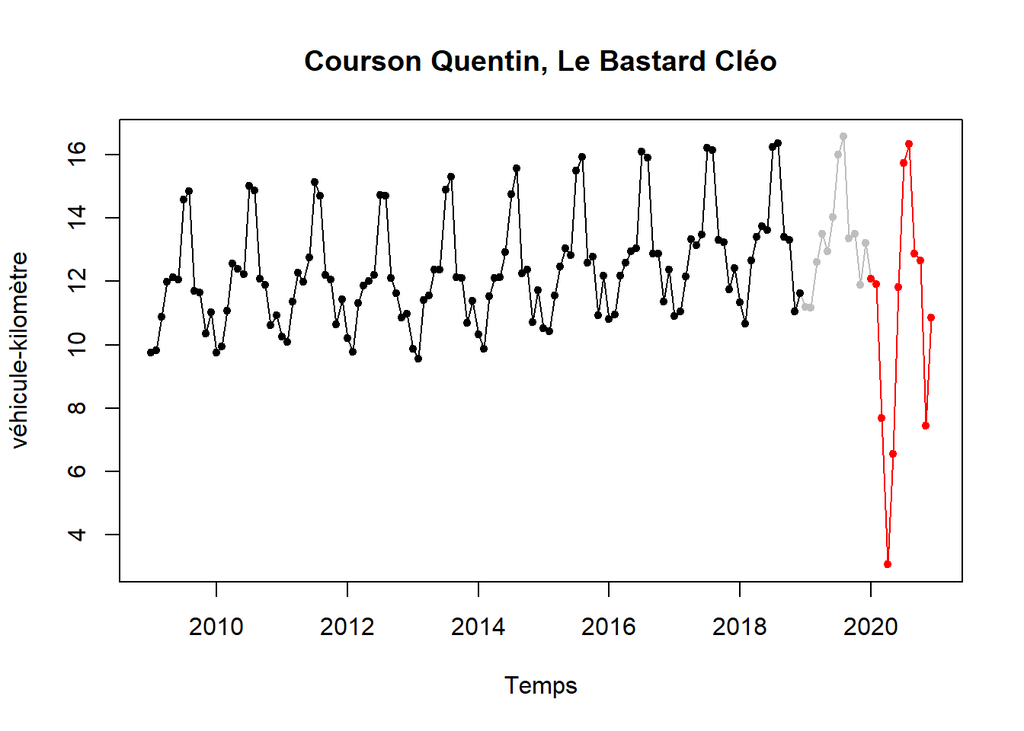

```r
plot(data.ts_comp, main = "Courson Quentin, Le Bastard Cléo", ylab="véhicule-kilomètre", xlab="Temps", col="grey")
points(data.ts_comp,pch=20, col="darkblue")
lines(data.ts_comp_2018,col="black", type="o", pch=20)
lines(data.ts_test_2019,col="gray", type="o", pch=20)
lines(data.ts_test_2020,col ="red", type="o", pch=20)
```

1. Saisonnalité La caractéristique la plus évidente du graphique est la forte saisonnalité annuelle.

Stabilité : L’amplitude de cette variation saisonnière (la distance entre le pic et le creux) apparaît relativement stable au fil des années. Cela suggère l’utilisation d’un modèle additif pour la désaisonnalisation, où la saisonnalité s’ajoute à la tendance de manière constante.

2. Tendance Faible Tendance Positive : En observant l’évolution des creux et des pics successifs, il y a une légère tendance à la hausse du volume global de trafic sur la période 2009-2018.

Nature de la Tendance : Cette tendance est lente et semble être globalement linéaire sur cette décennie.

3. Autres Observations Variabilité : La variabilité autour du motif saisonnier et de la tendance est relativement faible et ne semble pas augmenter significativement avec le temps.

## Autocorrélogramme

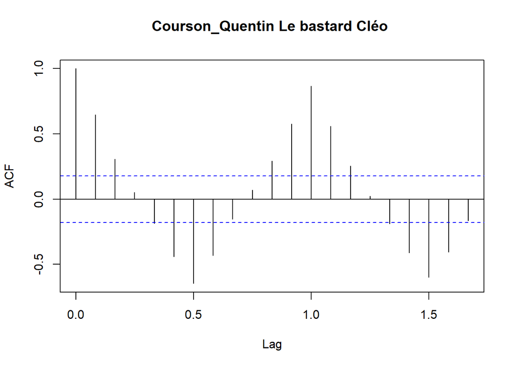

```r
acf(data.ts_av, main="Courson_Quentin Le bastard Cléo ")
```

## Visualisation par années

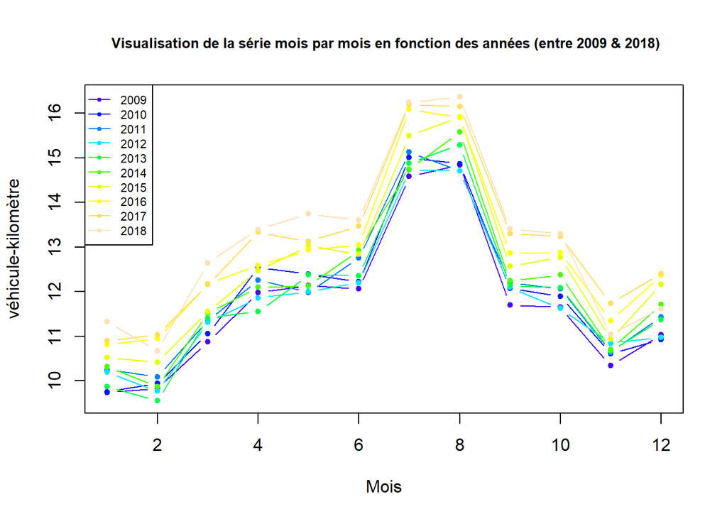

```r
library(pastecs)
dat.bbtab = buysbal(x=data.ts_av, # la série
                    frequency = 12 # nb obs / année
                    )
# courbes superposées
matplot( t(dat.bbtab), # transposé :  1 courbe <=> 1 année
        type='b',
        xlab="Mois", ylab="véhicule-kilomètre",
        col=topo.colors(10), # une couleur par année
        pch=20, lty=1,
        main=" Visualisation de la série mois par mois en fonction des années (entre 2009 & 2018)",
        cex.main=0.8)
legend(
  "topleft",
  legend =rownames(dat.bbtab),
  col = topo.colors(10),
  lty = 1,
  pch = 20,
  cex = 0.7,
    xpd = TRUE)
```

1. Motif Saisonnieer (Saisonnalité) Périodicité et Amplitude : Le graphique superpose les courbes d’évolution du trafic pour chaque année (chaque couleur représente une année). Il confirme la forte saisonnalité annuelle.

Pics et Creux :

Le pic de trafic se situe clairement aux mois 7 et 8 (Juillet et Août), correspondant aux périodes de vacances estivales.

Les creux se situent généralement en début d’année (mois 1 et 2) et en fin d’année (mois 11 et 12).

Modèle Additif : Les courbes des différentes années sont approximativement parallèles. L’amplitude des fluctuations saisonnières ne semble pas augmenter significativement avec le niveau du trafic. Ceci est une indication forte en faveur de l’utilisation d’un modèle saisonnier additif (où la saisonnalité est constante et s’ajoute à la tendance).

2. Tendance (Évolution inter-années) Tendance Positive : Globalement, les courbes pour les années les plus récentes (couleurs plus chaudes, ex: 2018 en jaune clair) sont situées au-dessus des courbes des années antérieures (couleurs plus froides, ex: 2009 en bleu foncé).

Ceci confirme la présence d’une faible tendance linéaire positive dans la série. Le trafic moyen augmente légèrement d’année en année. On choisit donc un modèle additif car on remarque que sur les visualisations chronogramme et par années, la saisonnalité n’évolue pas. De plus on remarque une faible tendance linéaire croissante. Enfin on remarque une saisonnalité assez marquée annuelle.

# Etude de la tendance et saisonnalité

## Etude de la tendance (paramètrique)

```r
T=length(data.ts_av) #longueur de la série
time=1:T #temps observé
data_av.ajust_tend = lm(data.ts_av ~ time)
round(data_av.ajust_tend$coefficients,4)
```

```
## (Intercept)        time
##     11.4533      0.0146
```

```r
tendest = ts(data_av.ajust_tend$fitted.values, start=c(2009,01), end=c(2018,12), frequency=12)
```

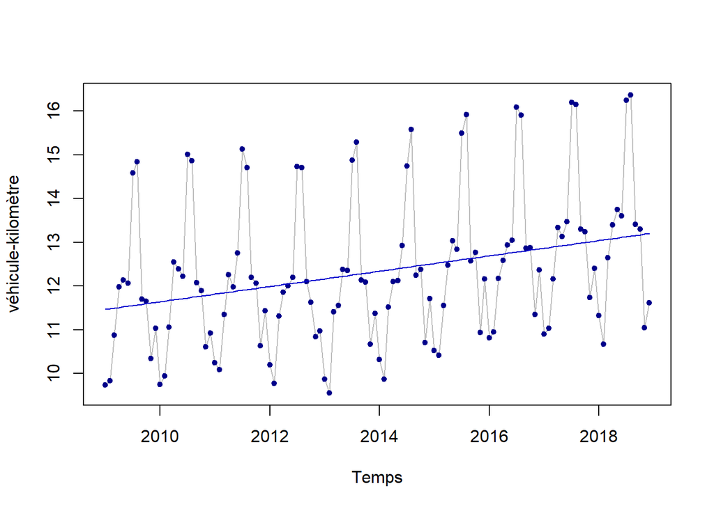

```r
plot(data.ts_av, ylab="véhicule-kilomètre", xlab="Temps", col="grey" )
points(data.ts_av,pch=20, col="darkblue")
lines(tendest, col="blue3")
```

Tendance Paramétrique : Le modèle linéaire ajuste une droite croissante avec une ordonnée à l’origine de 11.453 (trafic moyen au temps $t=0$) et une pente faible mais positive de 0.01455 (augmentation moyenne de 0.01455 Veh_km par mois).

## Etude de la saisonnalité (paramètrique)

```r
data.ts_av_sanstend = data.ts_av - tendest
T=length(data.ts_av) #longueur de la série
time=1:T #temps observé
S=12
sint = sin(2*pi*time/S)
cost = cos(2*pi*time/S)
sais_ajust=lm(data.ts_av_sanstend[time]~sint+cost)
round(sais_ajust$coefficients,4)
```

```
## (Intercept)        sint        cost
##      0.0000     -1.1078     -1.5999
```

```r
saisest = ts(sais_ajust$fit,
             start=c(2009,01),
             frequency=12)
```

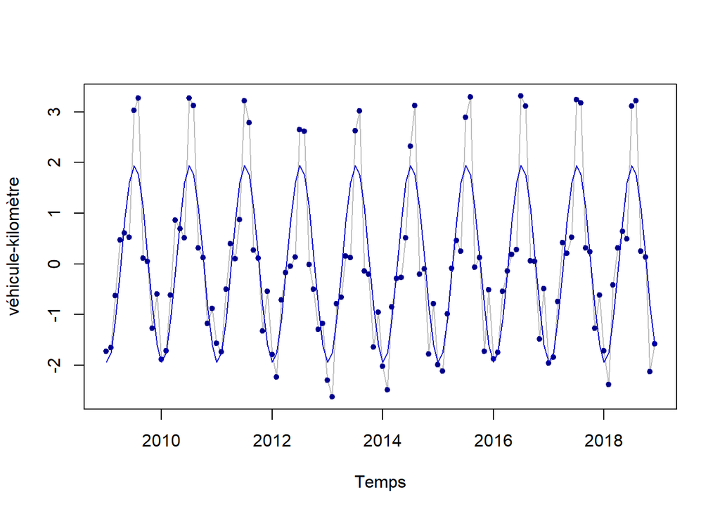

```r
data.ts_av_sanstend = data.ts_av - tendest
plot(data.ts_av_sanstend, ylab="véhicule-kilomètre", xlab="Temps", col="grey", )
points(data.ts_av_sanstend,pch=20, col="darkblue")
lines(saisest, col="blue3")
```

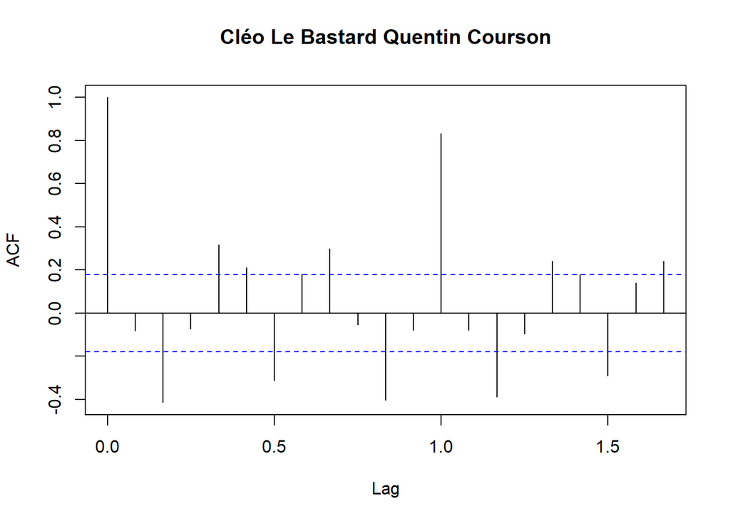

```r
tend_sais = tendest + saisest
bruit = data.ts_av_sanstend - saisest
acf(bruit , main = "Cléo Le Bastard Quentin Courson")
```

## Prédiction pour 2019

```r
T=length(data.ts_av)
N=12
n = (T+1): (T+N)
nd=data.frame(time=n)
temp.pred = predict(data_av.ajust_tend, newdata=nd)
nd=data.frame(sint=sin(2*pi*n/S), cost=cos(2*pi*n/S))
sais.pred=predict(sais_ajust,newdata=nd)
data.predp=temp.pred+sais.pred
data.predp.ts=ts(data.predp,start=c(2019,01), end = c(2019,6),frequency=12)
```

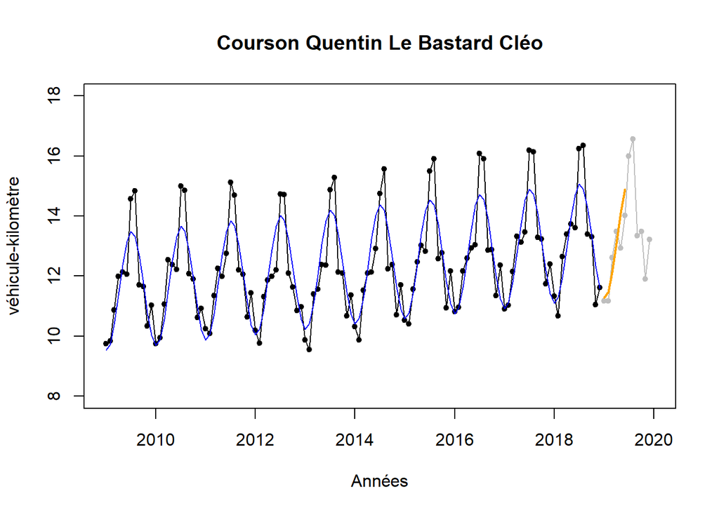

```r
data.ts_test=window(x = data.ts_comp, # la série d'origine
                 start = c(2019,1), #période à extraire
                 end=c(2019,12)
                 )
plot(data.ts_av, xlab="Années", ylab="véhicule-kilomètre", xlim=c(2009,2020),ylim=c(8,18), type="o", pch=20, main="Courson Quentin Le Bastard Cléo",col="black")
lines(data.ts_test,col="grey", type="o", pch=20)
lines(data.predp.ts, col="orange", lwd=2)
lines(tend_sais, col ="blue")
```

Tendance : On observe une faible tendance linéaire croissante dans le volume global de véhicule-kilomètre sur cette période.

Modèle Paramétrique : Le modèle utilisé est généralement de forme additive, combinant une tendance linéaire et une saisonnalité modélisée par des fonctions sinusoïdales/cosinusoïdales (ou par moyennes saisonnières).

Performance du Modèle :

Le modèle suit la forme saisonnière des données réelles (les pics et creux se produisent au bon moment).

## Prédiction pour 2019 et 2020

```r
T=length(data.ts_av)
N=24
n = (T+1): (T+N)
nd=data.frame(time=n)
temp.pred = predict(data_av.ajust_tend, newdata=nd)
nd=data.frame(sint=sin(2*pi*n/S), cost=cos(2*pi*n/S))
sais.pred=predict(sais_ajust,newdata=nd)
data.pred=temp.pred+sais.pred
data.pred.ts=ts(data.pred,start=c(2019,01), frequency=12)
```

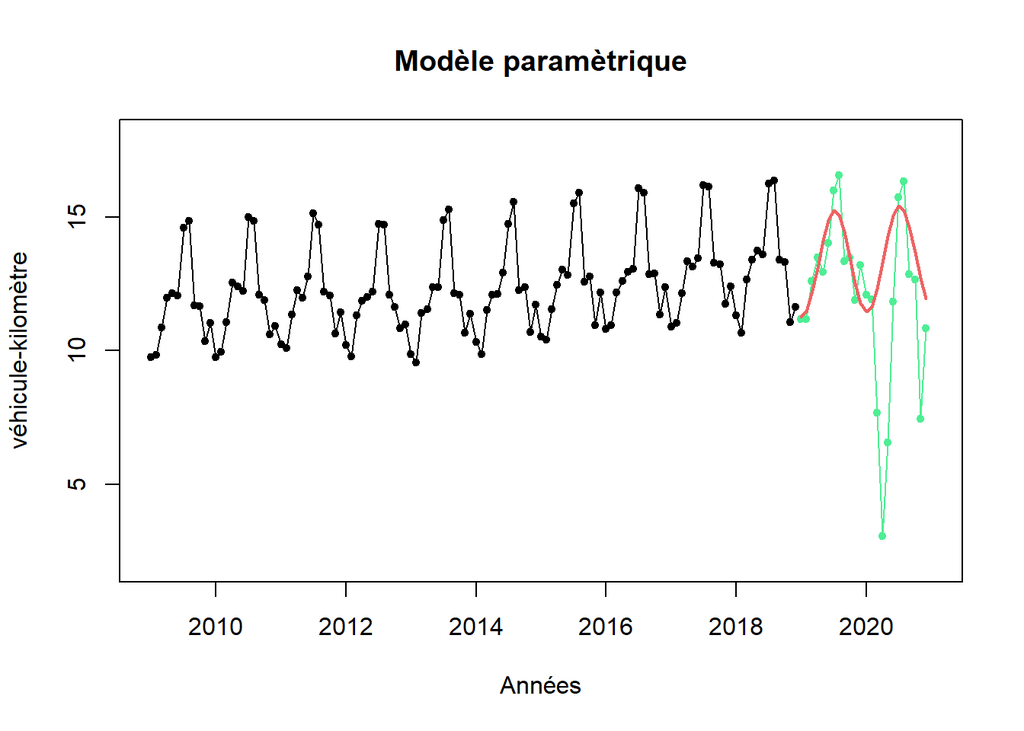

```r
data.ts_test=window(x = data.ts_comp, # la série d'origine
                 start = c(2019,1), #période à extraire
                 end=c(2020,12)
                 )
plot(data.ts_av, xlab="Années", ylab="véhicule-kilomètre", xlim=c(2009,2021),ylim=c(2,18), type="o", pch=20, main="Modèle paramètrique",col="black")
lines(data.ts_test,col="seagreen2", type="o", pch=20)
lines(data.pred.ts, col="indianred2", lwd=2)
```

2. Période de Prédiction (2019)Prédiction du Modèle (Ligne rouge) : La courbe rouge représente les valeurs prédites par le modèle paramétrique (Tendance linéaire + Saisonnalité sinusoïdale ou équivalente).Données Réelles (Points verts) : Les points verts représentent les vraies valeurs du trafic observées pour l’année 2019.

Performance :Le modèle paramétrique (rouge) capte correctement le motif saisonnier des données réelles de 2019 (verts), avec les pics en été et les creux en hiver.

Le modèle paramétrique n’est donc pas le plus performant pour la prévision. ## Etude de la tendance (non paramètrique)

```r
# Moyenne mobile d'ordre 12
p=12
MM12= filter(x=data.ts_av,
            filter=rep(1/p,p))
# Moyenne mobile d'ordre 4
p=4
MM4=filter(x=data.ts_av,
            filter=c(1/(2*p), rep(1/p,p-1), 1/(2*p)))
```

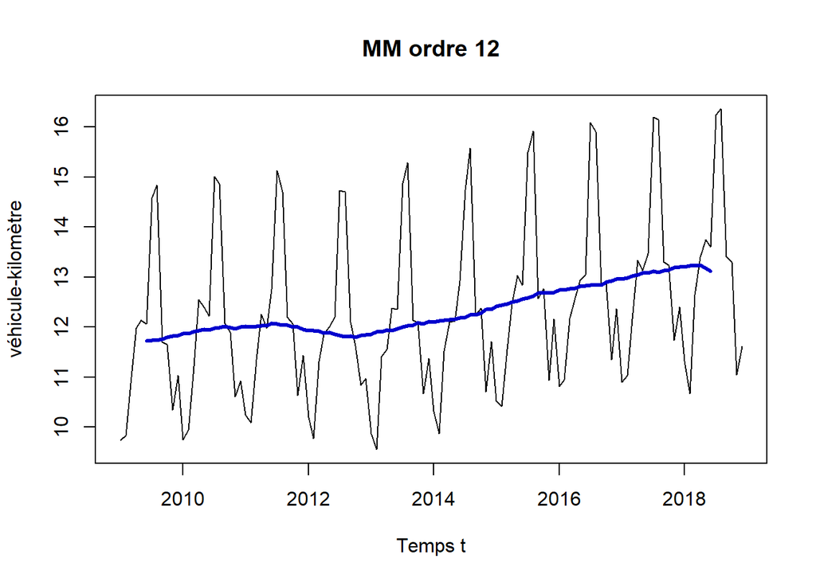

```r
#Graph1 MM3
plot(data.ts_av, xlab="Temps t", ylab="véhicule-kilomètre")
lines(MM12, col="blue3",lwd=3)
title("MM ordre 12")
```

MM Ordre 12 (Graphique) : Le graphique de la Moyenne Mobile d’ordre 12 (MM3) montre une ligne bleue lisse qui capture bien la tendance globale à la hausse de la série data.ts_av (2009-2018), confirmant la faible tendance positive.

## Etude de la saisonnalité (non paramètrique)

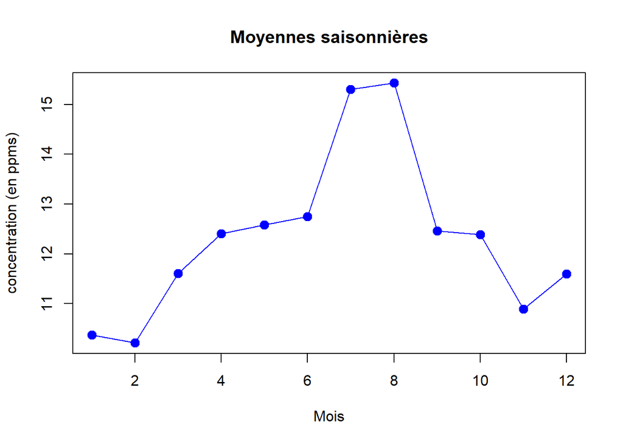

```r
#Moyennes saisonnières
moy_sais=aggregate(data.ts_av~cycle(data.ts_av),FUN=mean)
#représentation graphique du motif saisonnier
plot(moy_sais, xlab="Mois", ylab="concentration (en ppms)",col="blue", cex=2, type="o", pch=20, main="Moyennes saisonnières")
```

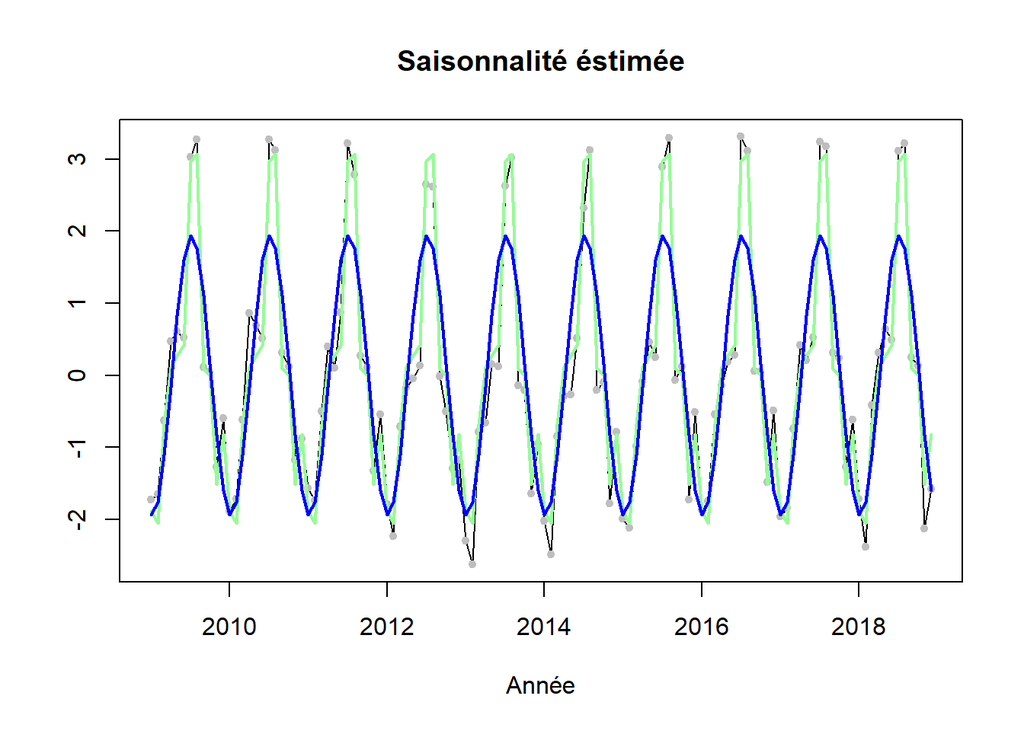

```r
S=12
moy_sais=aggregate(data.ts_av_sanstend~cycle(data.ts_av_sanstend),FUN=mean)
#nb d'années pendant la période d'observation =P
P=length(data.ts_av)/S
#on répète le motif des moyennes saisonnières autant de fois qu'on a d'années
moy_sais=rep(x=moy_sais$data.ts_av, times=P)
#série des moyennes saisonnières
moy_sais.ts=ts(moy_sais, start=c(2009, 1), end=c(2018,12), freq=12)
plot(data.ts_av_sanstend, xlab="Année", ylab=" ", main="Saisonnalité éstimée")
points(data.ts_av_sanstend, pch=20, col="grey")
lines(moy_sais.ts,col="palegreen", lwd=2)
lines(saisest,col="blue", lwd=2)
```

Prédiction du Modèle (Ligne rouge) :

La ligne rouge représente la prédiction extrapolée du modèle paramétrique (Tendance linéaire + Saisonnalité).

Cette ligne continue de suivre le motif saisonnier normal observé historiquement, avec la tendance linéaire positive extrapolée. Le modèle prédit donc un trafic stable et saisonnier pour 2020.

Données Réelles (Points verts) :

Les points verts montrent la réalité du trafic en 2019 et 2020.

Année 2020 : Les données réelles (points verts) présentent une chute brutale et anormale au printemps 2020 (Avril-Mai, valeur proche de 3), correspondant probablement aux confinements. Le trafic réel est alors bien en dessous de toute prédiction.

3. Conclusion sur le Modèle Limitation Exogène : L’écart massif entre la prédiction (rouge) et la réalité (verts) en 2020 (chute à 3) met en lumière la limite des modèles basés uniquement sur la structure interne (tendance, saisonnalité) face à des événements externes imprévus et sans précédent.

```r
T=length(data.ts_av)
N=12
n = (T+1): (T+N)
nd=data.frame(time=n)
temp.pred = predict(data_av.ajust_tend, newdata=nd)
data.pred=temp.pred+moy_sais
data.pred.ts=ts(data.pred,start=c(2019,01), end=c(2019,12),frequency=12)
```

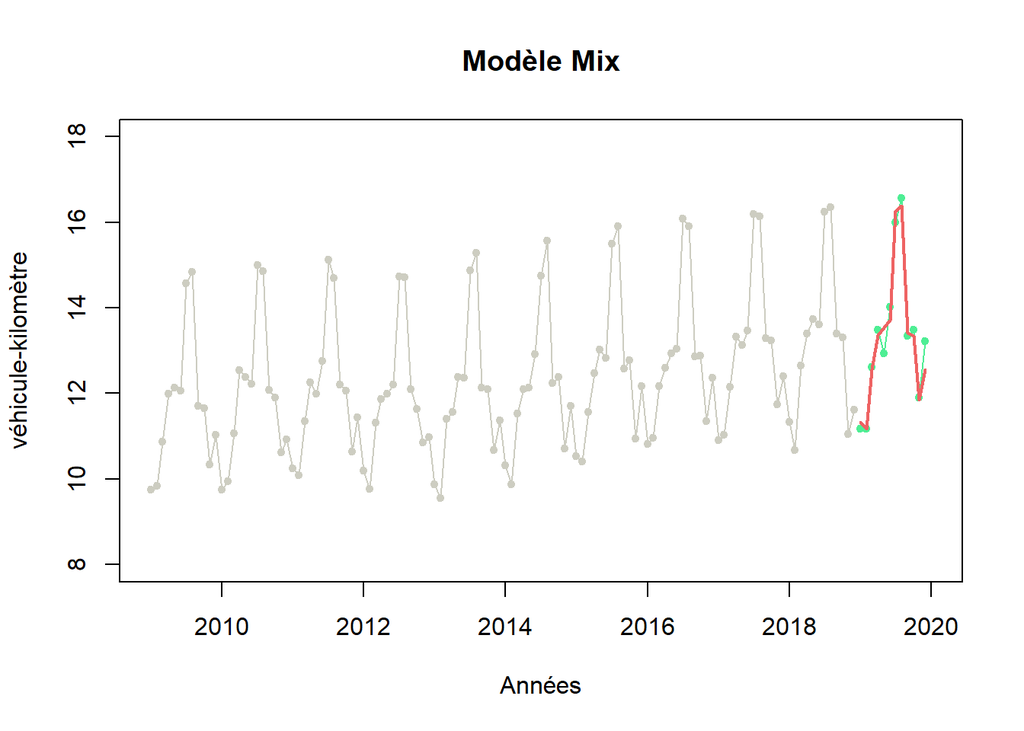

```r
data.ts_test=window(x = data.ts_comp, # la série d'origine
                 start = c(2019,1), #période à extraire
                 end=c(2019,12)
                 )
plot(data.ts_av, xlab="Années", ylab="véhicule-kilomètre", xlim=c(2009,2020),ylim=c(8,18), type="o", pch=20, main="Modèle Mix",col="ivory3")
lines(data.ts_test,col="seagreen2", type="o", pch=20)
lines(data.pred.ts, col="indianred2", lwd=2)
```

Modèle Mix (Tendance Linaire + Saisonnalité NP) :

La ligne rouge (prédiction) se superpose très bien à la ligne verte (valeurs réelles de 2019), justifiant son EQM très faible.

## Prédiction non paramètrique:

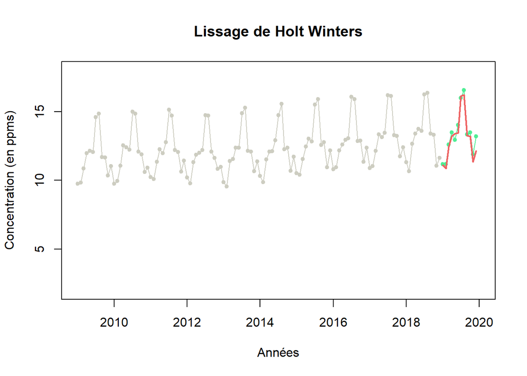

```r
data.Holt=HoltWinters(x=data.ts_av)
data.Holt.pred=predict(data.Holt,
               n.ahead=length(data.ts_test),
               prediction.interval=FALSE)
plot(data.ts_av, xlab="Années", ylab="Concentration (en ppms)", xlim=c(2009,2020), ylim=c(2,18), type="o", pch=20, main="Lissage de Holt Winters",col="ivory3")
lines(data.ts_test,col="seagreen2", type="o", pch=20)
lines(data.Holt.pred, col="indianred2", lwd=2)
```

Lissage de Holt-Winters (Non Paramétrique) :

La ligne rouge (prédiction) suit bien les données de 2019, mais avec une EQM plus élevée que le modèle Mix.

## EQM:

```r
eqmparam=mean((data.predp.ts-data.ts_test)^2)
eqmMix=mean((data.pred.ts-data.ts_test)^2)
eqmHolt=mean((data.Holt.pred-data.ts_test)^2)
eqmparam
```

```
## [1] 0.4324843
```

```r
eqmMix
```

```
## [1] 0.08870845
```

```r
eqmHolt
```

```
## [1] 0.2034893
```

Conclusion sur les modèles : Le modèle Mix (Tendance paramétrique + Saisonnalité par moyennes saisonnières) présente l’EQM la plus basse (0.0887) pour la période de test 2019, ce qui en fait le meilleur modèle prédictif parmi les trois évalués.